# Exploratory Data Analysis on Amazon Kindle Book Sales

Agomuo Kelechi

# Exploratory Data Analysis of Amazon Kindle Books

Sales is the most important aspect of any business; thus, all businesses need to pay attention to their sales data.

Sales data is any information that is human and machine-readable and is useful to sales teams and the organization. It aids in decision-making, greater client comprehension, and enhancing future performance within the organization.

Sales data can provide insightful information about a sales team’s effectiveness, and aid in the creation of better strategies. It can also,

- Help improve organizational decision-making,
- Provide actionable information about a sales team’s performance,
- Assist sales representatives in avoiding pursuing customers who are a bad fit, and
- Inform new opportunities that sales teams wouldn’t otherwise detect, and assist in forecasting future sales.

Sales data should therefore not be neglected by any business or organization. In this report, I performed an exploratory data analysis on Amazon Kindle Books.

## Objectives

The objectives include to:

- Determine the most popular authors based on the number of books they have released and their ratings.
- Investigate the influence of Kindle Unlimited on book sales and popularity.
- Assess the impact of the “Best Seller” and “Editors’ Pick” tags on book sales.
- Examine book publication trends over time and look for seasonal patterns.
- Learn about the sales and popularity of kindle books based on their categories.

## Data Exploration

We’ll begin our data exploration by installing and loading all necessary packages required to perform our analysis.

```r
#Load R packages
library(tidyverse)
```

```r
library(readr)
library(ggplot2)
library(gridExtra)
library(dplyr)
library(corrplot)
library(stargazer)
```

### Importing and inspecting our data

After loading our packages, the first thing we did was to import our data set and inspect its structure.

```r
#Import sales data for exploration
salesData <- read.csv("kindle_data-v2.csv")
dim(salesData)
```

```
## [1] 133102     16
```

```r
str(salesData)
```

```
## 'data.frame':    133102 obs. of  16 variables:
##  $ asin             : chr  "B00TZE87S4" "B08WCKY8MB" "B09KPS84CJ" "B07S7QPG6J" ...
##  $ title            : chr  "Adult Children of Emotionally Immature Parents: How to Heal from Distant, Rejecting, or Self-Involved Parents" "From Strength to Strength: Finding Success, Happiness, and Deep Purpose in the Second Half of Life" "Good Inside: A Guide to Becoming the Parent You Want to …
##  $ author           : chr  "Lindsay C. Gibson" "Arthur C. Brooks" "Becky Kennedy" "Dolly Alderton" ...
##  $ soldBy           : chr  "Amazon.com Services LLC" "Penguin Group (USA) LLC" "HarperCollins Publishers" "HarperCollins Publishers" ...
##  $ imgUrl           : chr  "https://m.media-amazon.com/images/I/713KZTsaYpL._AC_UY218_.jpg" "https://m.media-amazon.com/images/I/A1LZcJFs9EL._AC_UY218_.jpg" "https://m.media-amazon.com/images/I/71RIWM0sv6L._AC_UY218_.jpg" "https://m.media-amazon.com/images/I/71QdQpTiKZL._AC_UY218_.jpg" ...
##  $ productURL       : chr  "https://www.amazon.com/dp/B00TZE87S4" "https://www.amazon.com/dp/B08WCKY8MB" "https://www.amazon.com/dp/B09KPS84CJ" "https://www.amazon.com/dp/B07S7QPG6J" ...
##  $ stars            : num  4.8 4.4 4.8 4.2 4.7 4.6 4.6 4.6 4.7 4.7 ...
##  $ reviews          : int  0 0 0 0 0 0 0 0 0 0 ...
##  $ price            : num  9.99 16.99 16.99 9.95 13.99 ...
##  $ isKindleUnlimited: chr  "False" "False" "False" "True" ...
##  $ category_id      : int  6 6 6 6 6 6 6 6 6 6 ...
##  $ isBestSeller     : chr  "True" "False" "False" "False" ...
##  $ isEditorsPick    : chr  "False" "False" "True" "True" ...
##  $ isGoodReadsChoice: chr  "False" "False" "False" "False" ...
##  $ publishedDate    : chr  "2015-06-01" "2022-02-15" "2022-09-13" "2020-02-25" ...
##  $ category_name    : chr  "Parenting & Relationships" "Parenting & Relationships" "Parenting & Relationships" "Parenting & Relationships" ...
```

```r
head(salesData)
```

|  | asin | title | author | soldBy | imgUrl | productURL | stars | reviews | price | isKindleUnlimited | category_id | isBestSeller | isEditorsPick | isGoodReadsChoice | publishedDate | category_name |
| --- | --- | --- | --- | --- | --- | --- | --- | --- | --- | --- | --- | --- | --- | --- | --- | --- |
| 1 | B00TZE87S4 | Adult Children of Emotionally Immature Parents: How to Heal from Distant, Rejecting, or Self-Involved Parents | Lindsay C. Gibson | Amazon.com Services LLC | https://m.media-amazon.com/images/I/713KZTsaYpL._AC_UY218_.jpg | https://www.amazon.com/dp/B00TZE87S4 | 4.8 | 0 | 9.99 | False | 6 | True | False | False | 2015-06-01 | Parenting & Relationships |
| 2 | B08WCKY8MB | From Strength to Strength: Finding Success, Happiness, and Deep Purpose in the Second Half of Life | Arthur C. Brooks | Penguin Group (USA) LLC | https://m.media-amazon.com/images/I/A1LZcJFs9EL._AC_UY218_.jpg | https://www.amazon.com/dp/B08WCKY8MB | 4.4 | 0 | 16.99 | False | 6 | False | False | False | 2022-02-15 | Parenting & Relationships |
| 3 | B09KPS84CJ | Good Inside: A Guide to Becoming the Parent You Want to Be | Becky Kennedy | HarperCollins Publishers | https://m.media-amazon.com/images/I/71RIWM0sv6L._AC_UY218_.jpg | https://www.amazon.com/dp/B09KPS84CJ | 4.8 | 0 | 16.99 | False | 6 | False | True | False | 2022-09-13 | Parenting & Relationships |
| 4 | B07S7QPG6J | Everything I Know About Love: A Memoir | Dolly Alderton | HarperCollins Publishers | https://m.media-amazon.com/images/I/71QdQpTiKZL._AC_UY218_.jpg | https://www.amazon.com/dp/B07S7QPG6J | 4.2 | 0 | 9.95 | True | 6 | False | True | False | 2020-02-25 | Parenting & Relationships |
| 5 | B00N6PEQV0 | The Seven Principles for Making Marriage Work: A Practical Guide from the Country's Foremost Relationship Expert | John Gottman | Random House LLC | https://m.media-amazon.com/images/I/813o4WOs+wL._AC_UY218_.jpg | https://www.amazon.com/dp/B00N6PEQV0 | 4.7 | 0 | 13.99 | False | 6 | False | False | False | 2015-05-05 | Parenting & Relationships |
| 6 | B000OVLKMM | The Glass Castle: A Memoir | Jeannette Walls | Simon and Schuster Digital Sales Inc | https://m.media-amazon.com/images/I/71td5GDUZML._AC_UY218_.jpg | https://www.amazon.com/dp/B000OVLKMM | 4.6 | 0 | 13.99 | False | 6 | False | False | False | 2005-03-01 | Parenting & Relationships |

From the above, we can see that our data has 16 variables and 133102 observations.

A critical look at each of the variables shows that some of the data types are not correct. So, let us normalize them before we proceed.

```r
#Normalize data types to fit the data
#convert isKindleunlimited to bool data type
salesData$isKindleUnlimited <- as.logical(salesData$isKindleUnlimited)
#Check if the data type has changed
class(salesData$isKindleUnlimited)
```

```
## [1] "logical"
```

```r
#convert isBestSeller, iseditorsPick, and isGood.. to bool data type
salesData$isBestSeller <- as.logical(salesData$isBestSeller)
salesData$isEditorsPick <- as.logical(salesData$isEditorsPick)
salesData$isGoodReadsChoice <- as.logical(salesData$isGoodReadsChoice)

#convert publishedDate to date data type
salesData$publishedDate <- as.Date(salesData$publishedDate)

#Let's check the structure of our data again
str(salesData)
```

```
## 'data.frame':    133102 obs. of  16 variables:
##  $ asin             : chr  "B00TZE87S4" "B08WCKY8MB" "B09KPS84CJ" "B07S7QPG6J" ...
##  $ title            : chr  "Adult Children of Emotionally Immature Parents: How to Heal from Distant, Rejecting, or Self-Involved Parents" "From Strength to Strength: Finding Success, Happiness, and Deep Purpose in the Second Half of Life" "Good Inside: A Guide to Becoming the Parent You Want to …
##  $ author           : chr  "Lindsay C. Gibson" "Arthur C. Brooks" "Becky Kennedy" "Dolly Alderton" ...
##  $ soldBy           : chr  "Amazon.com Services LLC" "Penguin Group (USA) LLC" "HarperCollins Publishers" "HarperCollins Publishers" ...
##  $ imgUrl           : chr  "https://m.media-amazon.com/images/I/713KZTsaYpL._AC_UY218_.jpg" "https://m.media-amazon.com/images/I/A1LZcJFs9EL._AC_UY218_.jpg" "https://m.media-amazon.com/images/I/71RIWM0sv6L._AC_UY218_.jpg" "https://m.media-amazon.com/images/I/71QdQpTiKZL._AC_UY218_.jpg" ...
##  $ productURL       : chr  "https://www.amazon.com/dp/B00TZE87S4" "https://www.amazon.com/dp/B08WCKY8MB" "https://www.amazon.com/dp/B09KPS84CJ" "https://www.amazon.com/dp/B07S7QPG6J" ...
##  $ stars            : num  4.8 4.4 4.8 4.2 4.7 4.6 4.6 4.6 4.7 4.7 ...
##  $ reviews          : int  0 0 0 0 0 0 0 0 0 0 ...
##  $ price            : num  9.99 16.99 16.99 9.95 13.99 ...
##  $ isKindleUnlimited: logi  FALSE FALSE FALSE TRUE FALSE FALSE ...
##  $ category_id      : int  6 6 6 6 6 6 6 6 6 6 ...
##  $ isBestSeller     : logi  TRUE FALSE FALSE FALSE FALSE FALSE ...
##  $ isEditorsPick    : logi  FALSE FALSE TRUE TRUE FALSE FALSE ...
##  $ isGoodReadsChoice: logi  FALSE FALSE FALSE FALSE FALSE FALSE ...
##  $ publishedDate    : Date, format: "2015-06-01" "2022-02-15" ...
##  $ category_name    : chr  "Parenting & Relationships" "Parenting & Relationships" "Parenting & Relationships" "Parenting & Relationships" ...
```

So far, all our variables has been normalized to their correct data type.

### Checking for missing values

Our next task is to check for missing values in our data set.

```r
#Let's look for missing data
missing <- data.frame("TotalNa" = sapply(salesData, function(x) length(which(is.na(x))) )) %>%
  filter(TotalNa > 0) %>%
  arrange(TotalNa)
missing
```

|  | TotalNa |
| --- | --- |
| author | 1 |

This tells us that there’s only one missing value in the authors column. We can go ahead to know the exact location of this missing data using the code:

```r
#Where is the missing data located
#sapply(salesData, function(y) which(is.na(y)))
```

After executing the code, we found the mising value to be in the author’s column in row 130436.

Meanwhile, let’s inspect each column to know the uniqueness of each observation.

```r
#Let's check summary of each column with duplicates by summarizing each column
#I'll use a for look to iterate through each column in the table

# Firstly, let's create an empty list to store the summary tables
dupTables <- list()
# Let's use the for loop to iterate through each column in the salesData
for (col_name in names(salesData)) {
  # Create a summary table for the current column
  summaryTable <- salesData %>%
    group_by(!!sym(col_name)) %>%
    summarise(Count = n()) %>%
    filter(Count > 1) %>%
    arrange(desc(Count))

  # Store the summary table in the list with the column name as the list name
  dupTables[[col_name]] <- summaryTable
}
```

We used the for loop above to find out if there are duplicates in each column, if there are, we count the number of duplicates for each entry.

```r
#Are there duplicates in asin column
dup_asin <- dupTables[["asin"]]
dup_asin
```

| asin | Count |
| --- | --- |

This shows that there are no duplicates in *asin* column. all entries are unique.

```r
#Are there duplicates in the title column
dup_title <- dupTables[["title"]]
head(dup_title)
```

| title | Count |
| --- | --- |
| Organic Chemistry | 8 |
| Macroeconomics | 6 |
| College Algebra | 5 |
| Criminal Evidence | 5 |
| Social Psychology | 5 |
| The Richest Man in Babylon | 5 |

This shows that there are 1108 duplicated titles.

```r
#Are there duplicates in the author column
dup_author <- dupTables[["author"]]
head(dup_author)
```

| author | Count |
| --- | --- |
| Not Available | 424 |
| James Patterson | 212 |
| DK Eyewitness | 163 |
| DK | 155 |
| Captivating History | 120 |
| Fodor's Travel Guides | 115 |

This indicates that about 18511 authors appeared more than once. We also found the author named “Not Available”. This means that 424 authors are missing in our data set.

```r
#Let's check for other columns sequentially
dupTables[["soldBy"]]
```

| soldBy | Count |
| --- | --- |
| Amazon.com Services LLC | 84759 |
| Not Available | 9233 |
| Random House LLC | 5872 |
| Hachette Book Group | 4736 |
| Penguin Group (USA) LLC | 4385 |
| HarperCollins Publishers | 4328 |
| Macmillan | 3147 |
| Simon and Schuster Digital Sales Inc | 3047 |
| Penguin Random House Publisher Services | 2390 |
| JOHN WILEY AND SONS INC | 2386 |

[output cut: 36 more lines]

```r
dupTables[["imgUrl"]]
```

| imgUrl | Count |
| --- | --- |
| https://m.media-amazon.com/images/I/01RmK+J4pJL._AC_UY218_.gif | 105 |
| https://m.media-amazon.com/images/I/819lRSgrd1L._AC_UY218_.jpg | 5 |
| https://m.media-amazon.com/images/I/71ZIZHZM9RL._AC_UY218_.jpg | 4 |
| No Image Found | 3 |
| https://m.media-amazon.com/images/I/61U9Mi-LQ9L._AC_UY218_.jpg | 3 |
| https://m.media-amazon.com/images/I/61QRNyl5xiL._AC_UY218_.jpg | 2 |
| https://m.media-amazon.com/images/I/61ubNIMPAXS._AC_UY218_.jpg | 2 |
| https://m.media-amazon.com/images/I/61xjSyuYEJL._AC_UY218_.jpg | 2 |
| https://m.media-amazon.com/images/I/711a9KH4feS._AC_UY218_.jpg | 2 |
| https://m.media-amazon.com/images/I/713ZQ0Pe1-L._AC_UY218_.jpg | 2 |

[output cut: 73 more lines]

```r
dupTables[["productURL"]]
```

| productURL | Count |
| --- | --- |

```r
dupTables[["stars"]]
```

| stars | Count |
| --- | --- |
| 4.6 | 24163 |
| 4.5 | 22367 |
| 4.7 | 20049 |
| 4.4 | 16214 |
| 4.8 | 11730 |
| 4.3 | 10629 |
| 4.2 | 6337 |
| 5.0 | 4822 |
| 4.1 | 3679 |
| 4.9 | 3329 |

[output cut: 27 more lines]

```r
dupTables[["reviews"]]
```

| reviews | Count |
| --- | --- |
| 0 | 64670 |
| 1 | 695 |
| 2 | 515 |
| 3 | 458 |
| 4 | 421 |
| 5 | 399 |
| 8 | 384 |
| 6 | 343 |
| 10 | 327 |
| 7 | 318 |

[output cut: 4359 more lines]

```r
dupTables[["price"]]
```

| price | Count |
| --- | --- |
| 9.99 | 17122 |
| 4.99 | 12246 |
| 3.99 | 6668 |
| 2.99 | 6455 |
| 5.99 | 6009 |
| 11.99 | 5456 |
| 12.99 | 5184 |
| 14.99 | 4537 |
| 7.99 | 4390 |
| 8.99 | 4292 |

[output cut: 2775 more lines]

```r
dupTables[["isKindleUnlimited"]]
```

| isKindleUnlimited | Count |
| --- | --- |
| FALSE | 97287 |
| TRUE | 35815 |

```r
dupTables[["category_id"]]
```

| category_id | Count |
| --- | --- |
| 21 | 6272 |
| 11 | 6162 |
| 15 | 5955 |
| 6 | 5901 |
| 25 | 5747 |
| 16 | 5738 |
| 19 | 5724 |
| 24 | 5526 |
| 28 | 5517 |
| 10 | 5504 |

[output cut: 21 more lines]

```r
dupTables[["isBestSeller"]]
```

| isBestSeller | Count |
| --- | --- |
| FALSE | 130866 |
| TRUE | 2236 |

```r
dupTables[["isEditorsPick"]]
```

| isEditorsPick | Count |
| --- | --- |
| FALSE | 127481 |
| TRUE | 5621 |

```r
dupTables[["isGoodReadsChoice"]]
```

| isGoodReadsChoice | Count |
| --- | --- |
| FALSE | 131700 |
| TRUE | 1402 |

```r
dupTables[["publishedDate"]]
```

| publishedDate | Count |
| --- | --- |
| 0001-01-01 | 49016 |
| 2023-09-12 | 347 |
| 2023-09-05 | 338 |
| 2023-09-26 | 329 |
| 2023-09-19 | 310 |
| 2023-08-22 | 280 |
| 2023-08-01 | 234 |
| 2009-10-13 | 227 |
| 2023-05-02 | 213 |
| 2022-11-01 | 206 |

[output cut: 5564 more lines]

```r
dupTables[["category_name"]]
```

| category_name | Count |
| --- | --- |
| Mystery, Thriller & Suspense | 6272 |
| Engineering & Transportation | 6162 |
| Science & Math | 5955 |
| Parenting & Relationships | 5901 |
| Children's eBooks | 5747 |
| Teen & Young Adult | 5738 |
| Foreign Language | 5724 |
| Travel | 5526 |
| LGBTQ+ eBooks | 5517 |
| Computers & Technology | 5504 |

[output cut: 21 more lines]

The above codes show that *soldBy* has 46 duplicates with “Not Available” appearing 9233 times. The remainder of the columns has the following duplicates:

| Column Name | No. of Duplicates | No. of Missing Values |
| --- | --- | --- |
| imgUrl | 83 | 3 |
| productURL | 0 | 0 |
| stars | 37 | 0 |
| reviews | 4369 | 0 |
| price | 2785 | 0 |
| isKindleUnlimited | 2 | 0 |
| category_id | 31 | 0 |
| isBestSeller | 2 | 0 |
| isEditorsPick | 2 | 0 |
| isGoodReadsChoice | 2 | 0 |
| publishedDate | 5574 | 49016 |
| category_name | 31 | 0 |

The above shows that we have missing data to deal with in the *authors,* *soldBy*, and *publishedDate* columns. This is in addition to the NA earlier detected in the authors column.

How do we handle these missing data? The easiest way is to remove the associated rows. But before we proceed, we should have a justifiable reason to take such measure.

So, let us extract all the missing data in our data set.

```r
#Let's select only the missing data in our dataset
missing_data <- subset(salesData, author == "Not Available" | soldBy == "Not Available" | imgUrl == "No Image Found" | publishedDate == "0001-01-01")
str(missing_data)
```

```
## 'data.frame':    55302 obs. of  16 variables:
##  $ asin             : chr  "B00AEBEQUK" "B00AN2JPNI" "B0B69SQNJY" "B07FZPTDJ3" ...
##  $ title            : chr  "Expecting Better: Why the Conventional Pregnancy Wisdom Is Wrong--and What You Really Need to Know (The ParentD"| __truncated__ "Moms on Call | Basic Baby Care 0-6 Months | Parenting Book 1 of 3 (Moms On Call Parenting Books)" "A Little Pinprick (Rainey Paxton Series B…
##  $ author           : chr  "Emily Oster" "Laura Hunter LPN" "Paige Dearth" "Emily Oster" ...
##  $ soldBy           : chr  "Penguin Group (USA) LLC" "Amazon.com Services LLC" "Amazon.com Services LLC" "Penguin Group (USA) LLC" ...
##  $ imgUrl           : chr  "https://m.media-amazon.com/images/I/81NYWaTY6-S._AC_UY218_.jpg" "https://m.media-amazon.com/images/I/717AozsjVZL._AC_UY218_.jpg" "https://m.media-amazon.com/images/I/71GoPR+P0eL._AC_UY218_.jpg" "https://m.media-amazon.com/images/I/81ck+JH5TyL._AC_UY218_.jpg" ...
##  $ productURL       : chr  "https://www.amazon.com/dp/B00AEBEQUK" "https://www.amazon.com/dp/B00AN2JPNI" "https://www.amazon.com/dp/B0B69SQNJY" "https://www.amazon.com/dp/B07FZPTDJ3" ...
##  $ stars            : num  4.6 4.7 4.6 4.7 4.7 4.8 4.5 4.2 4.5 4.7 ...
##  $ reviews          : int  0 0 0 0 0 0 0 0 0 0 ...
##  $ price            : num  14.99 24.99 5.99 14.99 9.99 ...
##  $ isKindleUnlimited: logi  FALSE FALSE TRUE FALSE FALSE FALSE ...
##  $ category_id      : int  6 6 6 6 6 6 6 6 6 6 ...
##  $ isBestSeller     : logi  TRUE FALSE TRUE FALSE TRUE FALSE ...
##  $ isEditorsPick    : logi  FALSE FALSE FALSE FALSE FALSE FALSE ...
##  $ isGoodReadsChoice: logi  FALSE FALSE FALSE FALSE FALSE FALSE ...
##  $ publishedDate    : Date, format: "0001-01-01" "0001-01-01" ...
##  $ category_name    : chr  "Parenting & Relationships" "Parenting & Relationships" "Parenting & Relationships" "Parenting & Relationships" ...
```

This gives us a total of 55302 missing data. This is quite huge. If we decide to delete all rows with a missing data, we’ll have 77800 observations left, which is not too bad.

On the other hand, if we want to input all 55302 missing data, we may introduce bias in our analysis which could lead to misleading results.

Looking at the variables, you should understand that *author* and *soldBy* variables are critical to our analysis. What I would do is to remove all observations that has missing values in *author* and *soldBy* columns.

For our *publishedDate* variable, we can input random dates between the already existing date interval.

### Dealing with missing data

Firstly, let us remove the rows that coincide with all the missing variables.

```r
#Rows with 3 of the missing variables: author, soldBy and publishedDate
missing_var <- subset(salesData, author == "Not Available" &
                         soldBy == "Not Available" &
                         publishedDate == "0001-01-01")
head(missing_var)
```

|  | asin | title | author | soldBy | imgUrl | productURL | stars | reviews | price | isKindleUnlimited | category_id | isBestSeller | isEditorsPick | isGoodReadsChoice | publishedDate | category_name |
| --- | --- | --- | --- | --- | --- | --- | --- | --- | --- | --- | --- | --- | --- | --- | --- | --- |
| 15797 | B09ZLFWYMJ | Varcarolis Essentials of Psychiatric Mental Health Nursing - E-Book: A Communication Approach to Evidence-Based Care | Not Available | Not Available | https://m.media-amazon.com/images/I/71zk5uL+zWL._AC_UY218_.jpg | https://www.amazon.com/dp/B09ZLFWYMJ | 0.0 | 0 | 0.00 | FALSE | 15 | FALSE | FALSE | FALSE | 0001-01-01 | Science & Math |
| 21842 | B07JMQ3GCD | Slaughter | Not Available | Not Available | https://m.media-amazon.com/images/I/91MWqUvMuuL._AC_UY218_.jpg | https://www.amazon.com/dp/B07JMQ3GCD | 4.3 | 0 | 0.00 | FALSE | 21 | FALSE | FALSE | FALSE | 0001-01-01 | Mystery, Thriller & Suspense |
| 27976 | B0C6JGJ7RJ | Not Found | Not Available | Not Available | No Image Found | https://www.amazon.com/dp/B0C6JGJ7RJ | 0.0 | 0 | 0.00 | FALSE | 26 | FALSE | FALSE | FALSE | 0001-01-01 | Crafts, Hobbies & Home |
| 55370 | B006WLOMOQ | Advanced Spanish Step-by-Step: Master Accelerated Grammar to Take Your Spanish to the Next Level (Easy Step-by-Step Series) (Spanish Edition) | Not Available | Not Available | https://m.media-amazon.com/images/I/715rBi9jVnL._AC_UY218_.jpg | https://www.amazon.com/dp/B006WLOMOQ | 4.7 | 551 | 9.99 | FALSE | 19 | FALSE | FALSE | FALSE | 0001-01-01 | Foreign Language |
| 57118 | B094QQLD7C | La otra Miss Bridgerton (Rokesby nº 3) (Spanish Edition) | Not Available | Not Available | https://m.media-amazon.com/images/I/81+IzVvBNcS._AC_UY218_.jpg | https://www.amazon.com/dp/B094QQLD7C | 4.5 | 735 | 6.41 | FALSE | 19 | FALSE | FALSE | FALSE | 0001-01-01 | Foreign Language |
| 57284 | B08VNP9JQ5 | Por culpa de Miss Bridgerton (Rokesby nº 1) (Spanish Edition) | Not Available | Not Available | https://m.media-amazon.com/images/I/716kBx7IM3L._AC_UY218_.jpg | https://www.amazon.com/dp/B08VNP9JQ5 | 4.4 | 1000 | 6.18 | FALSE | 19 | FALSE | FALSE | FALSE | 0001-01-01 | Foreign Language |

This gave us 31 observations that do not have author, soldBy and publishedDate. Thus, we remove these rows and have a total of 133071 left.

Let’s now remove those 31 observations from our data set. We have a new data set called **salesData_rev**.

```r
salesData_rev <- subset(salesData, author !="Not Available" |
                          soldBy != "Not Available" |
                          publishedDate != "0001-01-01")
head(salesData_rev)
```

|  | asin | title | author | soldBy | imgUrl | productURL | stars | reviews | price | isKindleUnlimited | category_id | isBestSeller | isEditorsPick | isGoodReadsChoice | publishedDate | category_name |
| --- | --- | --- | --- | --- | --- | --- | --- | --- | --- | --- | --- | --- | --- | --- | --- | --- |
| 1 | B00TZE87S4 | Adult Children of Emotionally Immature Parents: How to Heal from Distant, Rejecting, or Self-Involved Parents | Lindsay C. Gibson | Amazon.com Services LLC | https://m.media-amazon.com/images/I/713KZTsaYpL._AC_UY218_.jpg | https://www.amazon.com/dp/B00TZE87S4 | 4.8 | 0 | 9.99 | FALSE | 6 | TRUE | FALSE | FALSE | 2015-06-01 | Parenting & Relationships |
| 2 | B08WCKY8MB | From Strength to Strength: Finding Success, Happiness, and Deep Purpose in the Second Half of Life | Arthur C. Brooks | Penguin Group (USA) LLC | https://m.media-amazon.com/images/I/A1LZcJFs9EL._AC_UY218_.jpg | https://www.amazon.com/dp/B08WCKY8MB | 4.4 | 0 | 16.99 | FALSE | 6 | FALSE | FALSE | FALSE | 2022-02-15 | Parenting & Relationships |
| 3 | B09KPS84CJ | Good Inside: A Guide to Becoming the Parent You Want to Be | Becky Kennedy | HarperCollins Publishers | https://m.media-amazon.com/images/I/71RIWM0sv6L._AC_UY218_.jpg | https://www.amazon.com/dp/B09KPS84CJ | 4.8 | 0 | 16.99 | FALSE | 6 | FALSE | TRUE | FALSE | 2022-09-13 | Parenting & Relationships |
| 4 | B07S7QPG6J | Everything I Know About Love: A Memoir | Dolly Alderton | HarperCollins Publishers | https://m.media-amazon.com/images/I/71QdQpTiKZL._AC_UY218_.jpg | https://www.amazon.com/dp/B07S7QPG6J | 4.2 | 0 | 9.95 | TRUE | 6 | FALSE | TRUE | FALSE | 2020-02-25 | Parenting & Relationships |
| 5 | B00N6PEQV0 | The Seven Principles for Making Marriage Work: A Practical Guide from the Country's Foremost Relationship Expert | John Gottman | Random House LLC | https://m.media-amazon.com/images/I/813o4WOs+wL._AC_UY218_.jpg | https://www.amazon.com/dp/B00N6PEQV0 | 4.7 | 0 | 13.99 | FALSE | 6 | FALSE | FALSE | FALSE | 2015-05-05 | Parenting & Relationships |
| 6 | B000OVLKMM | The Glass Castle: A Memoir | Jeannette Walls | Simon and Schuster Digital Sales Inc | https://m.media-amazon.com/images/I/71td5GDUZML._AC_UY218_.jpg | https://www.amazon.com/dp/B000OVLKMM | 4.6 | 0 | 13.99 | FALSE | 6 | FALSE | FALSE | FALSE | 2005-03-01 | Parenting & Relationships |

Secondly, let’s remove all rows that have missing authors. But how many authors are missing in our data?

```r
author_NA <- salesData_rev %>%
  filter(author == "Not Available") %>%
  select(asin, author)
str(author_NA)
```

```
## 'data.frame':    393 obs. of  2 variables:
##  $ asin  : chr  "B098KJT3HT" "B092MV1G8G" "B0CB98BB43" "B00FTOANM2" ...
##  $ author: chr  "Not Available" "Not Available" "Not Available" "Not Available" ...
```

So, 393 authors are missing. Let’s remove these rows from our data.

```r
#Let's remove the rows where author is not aavailable
salesData_rev <- subset(salesData_rev, author != "Not Available")

#Let's be sure that all NA authors have been removed
head(subset(salesData_rev, author == "Not Available" | author == "NA"))
```

| asin | title | author | soldBy | imgUrl | productURL | stars | reviews | price | isKindleUnlimited | category_id | isBestSeller | isEditorsPick | isGoodReadsChoice | publishedDate | category_name |
| --- | --- | --- | --- | --- | --- | --- | --- | --- | --- | --- | --- | --- | --- | --- | --- |

Thirdly, we’ll remove all rows that have missing soldBy data.

```r
#How many rows do not have soldBy data
soldBy_NA <- subset(salesData_rev, soldBy == "Not Available")
#Remove the missing data from the data set
salesData_rev <- subset(salesData_rev, soldBy != "Not Available")
#check to be sure we've removed all NA
head(subset(salesData_rev, soldBy == "Not Available" | soldBy == "NA"))
```

| asin | title | author | soldBy | imgUrl | productURL | stars | reviews | price | isKindleUnlimited | category_id | isBestSeller | isEditorsPick | isGoodReadsChoice | publishedDate | category_name |
| --- | --- | --- | --- | --- | --- | --- | --- | --- | --- | --- | --- | --- | --- | --- | --- |

Now, we have a total of 123564 observations in our data set. Let’s check the total number of missing date data left.

```r
#No. of missing date data
publishedDate_NA <- salesData_rev %>%
  filter(publishedDate == "0001-01-01") %>%
  select(asin, author, publishedDate)
str(publishedDate_NA)
```

```
## 'data.frame':    45764 obs. of  3 variables:
##  $ asin         : chr  "B00AEBEQUK" "B00AN2JPNI" "B0B69SQNJY" "B07FZPTDJ3" ...
##  $ author       : chr  "Emily Oster" "Laura Hunter LPN" "Paige Dearth" "Emily Oster" ...
##  $ publishedDate: Date, format: "0001-01-01" "0001-01-01" ...
```

That’s a total of 45764 observations. We need to input these values using the interval between the beginning and ending date in our data.

Let’s first get the beginning and ending dates.

```r
#Let's get the beginning and ending date using max and min f(x)
publishedDate_allowed <- salesData_rev %>%
  filter(publishedDate != "0001-01-01") #remove the 0001-01-01 date
print(max(publishedDate_allowed$publishedDate)) #get maximum date = 2023-10-17
```

```
## [1] "2023-10-17"
```

```r
print(min(publishedDate_allowed$publishedDate)) #get minimum date = 1900-01-01
```

```
## [1] "1900-01-01"
```

We got the range 1900-01-01 to 2023-10-17. But, I am wondering if 1900-01-01 is right or an outlier. So, I want to know how close other dates are to it.

```r
#Let's group the dates to know how close they are to each other
publishedDate_group <- publishedDate_allowed %>%
  group_by(publishedDate) %>% #group by publishedDate
  summarise(count = n()) %>% #count how many rows has such date
  arrange(publishedDate) #sort by published date in ascending order
head(publishedDate_group)
```

| publishedDate | count |
| --- | --- |
| 1900-01-01 | 1 |
| 1942-02-01 | 1 |
| 1953-01-01 | 1 |
| 1954-11-30 | 1 |
| 1955-01-01 | 1 |
| 1958-05-31 | 1 |

The result shows that we have only one data with such date.

```r
#The title, author and genre of the book
theBook <- publishedDate_allowed %>%
  filter(publishedDate == "1900-01-01") %>%
  select(asin, title, author, category_name, publishedDate)
theBook
```

| asin | title | author | category_name | publishedDate |
| --- | --- | --- | --- | --- |
| B004HYFO3S | Chimpanzee Politics: Power and Sex among Apes | Frans de de Waal | Science & Math | 1900-01-01 |

A Google search revealed that this book was first published in 1982-01-01, see [Goodreads](https://www.goodreads.com/book/show/389530.Chimpanzee_Politics). A check on a few books shows that their dates are correct. so, we’ll change the 1900-01-01 to 1982-01-01.

```r
#Let's change the date 1900-01-01 to 1982-01-01
publishedDate_allowed["publishedDate"][publishedDate_allowed["publishedDate"] ==
                                         "1900-01-01"] <- 1982-01-01
salesData_rev["publishedDate"][salesData_rev["publishedDate"] ==
                                 "1900-01-01"] <- 1982-01-01
#Check to be sure the value has been replaced
head(subset(salesData_rev, publishedDate == "1900-01-01"))
```

| asin | title | author | soldBy | imgUrl | productURL | stars | reviews | price | isKindleUnlimited | category_id | isBestSeller | isEditorsPick | isGoodReadsChoice | publishedDate | category_name |
| --- | --- | --- | --- | --- | --- | --- | --- | --- | --- | --- | --- | --- | --- | --- | --- |

Let’s now generate random date between 1942-02-01 and 2023-10-01, and use them to replace the missing values.

```r
#Let's generate a random date between 2023-10-01 and 1942-02-01
#1. Check min date in date column after removing 1900-01-01
print(min(publishedDate_allowed$publishedDate))
```

```
## [1] "1942-02-01"
```

```r
#2. Replace 0001-01-01 with NA to account for missing values
salesData_rev["publishedDate"][salesData_rev["publishedDate"] ==
                                "0001-01-01"] <- NA
#3. Count the number of missing values to be sure is 45764
print(sum(is.na(salesData_rev$publishedDate)))
```

```
## [1] 45764
```

```r
#4. Generate 45764 random dates
set.seed(45001) #setting a seed to ensure the dates are reproducible
rd_dates <- as.Date(runif(45764, as.Date(1942-02-01),
                          as.Date(2023-10-01))) #generate the random dates
head(rd_dates)
```

```
## [1] "1975-05-28" "1975-07-02" "1975-06-01" "1975-05-08" "1975-06-26"
## [6] "1975-05-30"
```

```r
#5. Replace the missing dates with the random dates
salesData_rev$publishedDate[is.na(salesData_rev$publishedDate)] <- rd_dates
#Check to be sure that values have been replaced
head(subset(salesData_rev, publishedDate == "0001-01-01"))
```

| asin | title | author | soldBy | imgUrl | productURL | stars | reviews | price | isKindleUnlimited | category_id | isBestSeller | isEditorsPick | isGoodReadsChoice | publishedDate | category_name |
| --- | --- | --- | --- | --- | --- | --- | --- | --- | --- | --- | --- | --- | --- | --- | --- |

We are done with our missing values.

### Checking for Outliers and Data Anomalies

To check for outliers and anomalies in our data we use plots. Basically, we’ll use histograms and boxplots.

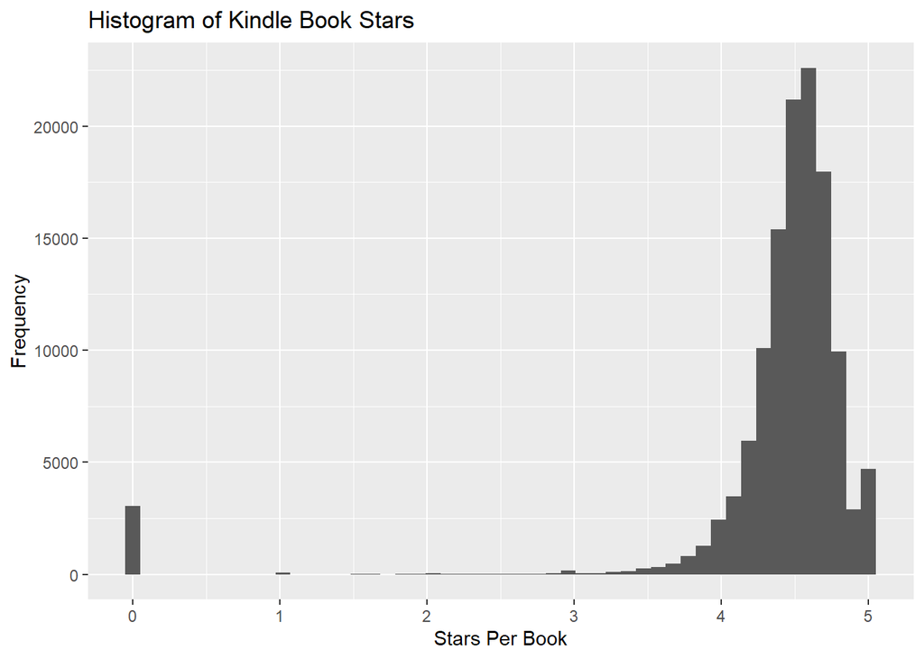

```r
#Checking for outliers and anomalies in our data
#1. Plot a histogram for stars column
ggplot(salesData_rev, aes(stars)) +
  geom_histogram(bins = 50) +
  labs(title = "Histogram of Kindle Book Stars",
       x = "Stars Per Book",
       y = "Frequency")
```

We have an outlier of the value 0. But this is not a problem because it represents books are not readers’ favourites. Since it’s part of the data, we’ll leave it.

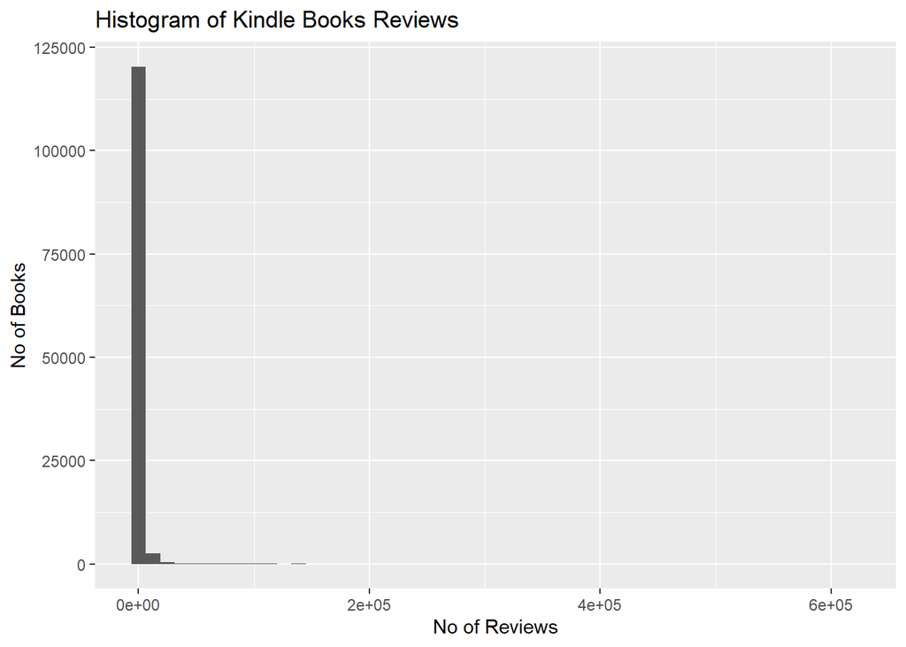

```r
#2. Checking for outliers in reviews
ggplot(salesData_rev, aes(reviews)) +
  geom_histogram(bins = 50) +
  labs(title = "Histogram of Kindle Books Reviews",
       x = "No of Reviews",
       y = "No of Books")
```

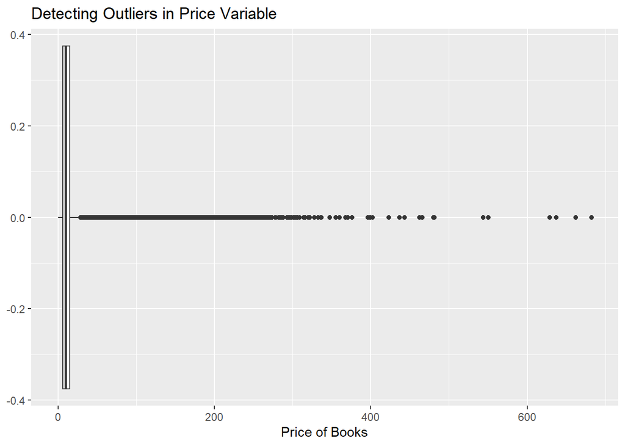

```r
#3. Check for outliers in price
ggplot(salesData_rev, aes(x = price)) +
  geom_boxplot() +
  labs(title = "Detecting Outliers in Price Variable",
       x = "Price of Books")
```

There are no major outliers in the prices of books. Though there are indications of outliers in the plot, but I believe that they are not out of ordinary. To inquire into the data, let’s know how many books has prices above $500.

```r
#Checking the No. of books with prices higher than $500
expensiveBooks <- salesData_rev %>%
  filter(price > 500) %>%
  summarise(count = n())
expensiveBooks
```

| count |
| --- |
| 6 |

There are only 6 such books. Further, we try to investigate to findout their true prices online. These are the 6 books.

```r
#What are the books
expensiveBooks_1 <- salesData_rev %>%
  filter(price > 500) %>%
  select(title, author, price)
head(expensiveBooks_1)
```

|  | title | author | price |
| --- | --- | --- | --- |
| 1 | Youmans and Winn Neurological Surgery E-Book: 4 - Volume Set | H. Richard Winn | 636.99 |
| 2 | The Collected Works of C. G. Jung: Revised and Expanded Complete Digital Edition | C. G. Jung | 549.99 |
| 3 | The Art of Aesthetic Surgery, Three Volume Set, Third Edition: Principles and Techniques | Foad Nahai | 543.99 |
| 4 | Drugs in Litigation: Damage Awards Involving Prescription and Nonprescription Drugs 2023 Edition | LexisNexis Editorial Staff | 682.00 |
| 5 | How to Write a Patent Application | Jeffrey G. Sheldon | 629.00 |
| 6 | Broker-Dealer Regulation | Clifford E. Kirsch | 662.00 |

Searching for them on Amazon shows that their prices are correct. Hence, nothing is out of ordinary.

## Correlations among Variables

So far we’ve completed our exploration. Before I create a dashboard to derive insights from the data, lets check for statistical relationships. To achieve this, we use correlation matrix and coefficients.

```r
#Creating a correlation matrix with discrete variables
#1. Select only numeric variables
salesData_Num <- salesData_rev %>%
  select_if(., is.numeric) %>%
  select(stars, reviews, price, category_id)
#2. Create the correlation matrix, rounding up to 4 decimal places
corMatrix <- round(cor(salesData_Num, use = "complete.obs"),4)
corMatrix[upper.tri(corMatrix)] <- NA
corMatrix
```

```
##               stars reviews   price category_id
## stars        1.0000      NA      NA          NA
## reviews      0.0306  1.0000      NA          NA
## price       -0.1278 -0.0495  1.0000          NA
## category_id  0.0259 -0.0482 -0.0812           1
```

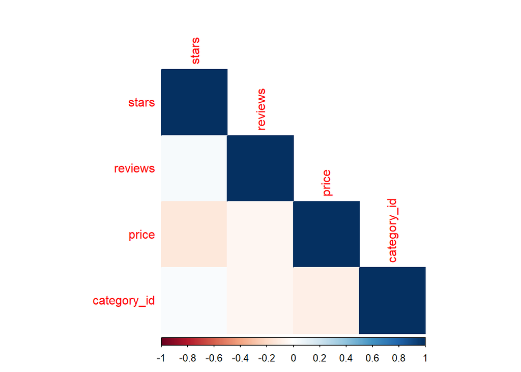

```r
#3. Create a heatmap of the correlation matrix
corrplot(corMatrix, method = "color", type = "lower")
```

The correlation matrix shows that non of the variables are correlated. Thus, we can use these variables on multiple linear regression to predict price. This is because there’ll be no trace of multicollinearity.

### Building a price prediction model

Let us finally build a model to predict the price of a book based on book genre and ratings. Book genre is represented by the category_id, and book ratings are determined by stars and reviews.

Therefore, our model is given by:

$Price = a + stars + reviews + category_id + u$

```r
#Creating a multiple regression model to predict price
priceModel <- lm(price ~ stars + reviews + category_id, salesData_Num)
#Display the results
summary(priceModel)
```

```
##
## Call:
## lm(formula = price ~ stars + reviews + category_id, data = salesData_Num)
##
## Residuals:
##    Min     1Q Median     3Q    Max
## -35.73  -9.19  -5.07  -0.03 650.40
##
## Coefficients:
##               Estimate Std. Error t value Pr(>|t|)
## (Intercept)  3.595e+01  3.951e-01   91.00   <2e-16 ***
## stars       -3.759e+00  8.509e-02  -44.17   <2e-16 ***
## reviews     -2.290e-04  1.299e-05  -17.62   <2e-16 ***
## category_id -2.175e-01  7.619e-03  -28.55   <2e-16 ***
## ---
## Signif. codes:  0 '***' 0.001 '**' 0.01 '*' 0.05 '.' 0.1 ' ' 1
##
## Residual standard error: 22.6 on 123560 degrees of freedom
## Multiple R-squared:  0.02485,    Adjusted R-squared:  0.02482
## F-statistic:  1049 on 3 and 123560 DF,  p-value: < 2.2e-16
```

```r
#Using the starhazer package to create a summary table
stargazer(priceModel, type = "text")
```

```
##
## =================================================
##                          Dependent variable:
##                     -----------------------------
##                                 price
## -------------------------------------------------
## stars                         -3.759***
##                                (0.085)
##
## reviews                      -0.0002***
##                               (0.00001)
##
## category_id                   -0.218***
##                                (0.008)
##
## Constant                      35.952***
##                                (0.395)
##
## -------------------------------------------------
## Observations                   123,564
## R2                              0.025
## Adjusted R2                     0.025
## Residual Std. Error     22.597 (df = 123560)
## F Statistic         1,049.489*** (df = 3; 123560)
## =================================================
## Note:                 *p<0.1; **p<0.05; ***p<0.01
```

From the above result we have:

$Price = 35.952 - 3.759 stars - 0.0002 reviews - 0.218 category_id$

The result shows that all the coefficients in our model are statistically significant. Therefore, they can be used to predict the price of a book.

## Using the Data to Answer Questions

Let’s focus on answering questions derived from the data.

### Who are the most popular authors?

To answer this question we use hindex. Here we consider the number of books published by each author and the total number of reviews. To consolidate on it, we also look at the average rating of each author. For the purpose of this report, we’ll consider authors that published 100 or more books, has average rating of 4.0, and at least 50000 reviews as the most popular authors. Let’s capture this in our code below.

```r
#Identifying popular authors
popularAuthor <- salesData_rev %>%
  group_by(author) %>%
  select(author, stars, reviews) %>%
  reframe(count = n(), stars = mean(stars), reviews = sum(reviews))
head(popularAuthor)
```

| author | count | stars | reviews |
| --- | --- | --- | --- |
| "Termite" Terry Singleton | 2 | 4.65 | 89 |
| (Chef) Dominique Ansel | 2 | 4.65 | 0 |
| (ISC)² Corporate | 1 | 3.80 | 78 |
| (John D.) J. D. Turner | 1 | 4.50 | 0 |
| (Journalist) Leigh Gallagher | 1 | 4.40 | 0 |
| (K.O.B.) Kayy0hBee | 1 | 0.00 | 0 |

```r
#Select the most popular authors from popularauthors
mostPopularAthors <- popularAuthor %>%
  filter(count >= 100 & stars >= 4.0 & reviews >= 50000)
head(mostPopularAthors)
```

| author | count | stars | reviews |
| --- | --- | --- | --- |
| DK | 131 | 4.657252 | 60686 |
| Hourly History | 103 | 4.256311 | 63398 |
| James Patterson | 150 | 4.438667 | 117723 |

From the above result, only 3 authors made the list. We can increase the list by adjusting any of the conditions above.

### Does kindle unlimited affect book sales and popularity?

Here, we’ll look at total book sales categorized as kindle unlimited and non. As a measure of popularity, we’ll use total reviews and average rating. So, we’ll consider which of the two categories has higher sales, higher average ratings and higher total reviews.

First, let’s select only discrete columns grouped by title so we can get the book sales column.

```r
#Group all discrete variables together by the book title
myBooks <- salesData_rev %>%
  group_by(title) %>%
  summarise(count = n(), price = mean(price), category_id = max(category_id),
            stars = mean(stars), reviews = sum(reviews),
            .groups = "drop")
#Add a calculated column for book sales
myBooks <- myBooks %>%
  mutate(BookSales = count * price)
head(myBooks)
```

| title | count | price | category_id | stars | reviews | BookSales |
| --- | --- | --- | --- | --- | --- | --- |
| " Arrête avec tes mensonges " - Prix Maison de la presse 2017 (Hors collection) (French Edition) | 1 | 10.99 | 19 | 4.3 | 3147 | 10.99 |
| "A Gift From The Stars" Kindle edition | 1 | 4.99 | 15 | 4.5 | 0 | 4.99 |
| "A Problem from Hell": America and the Age of Genocide | 1 | 15.99 | 14 | 4.6 | 877 | 15.99 |
| "A" is for Alibi: A Kinsey Millhone Mystery | 1 | 9.99 | 21 | 4.1 | 0 | 9.99 |
| "All the Real Indians Died Off": And 20 Other Myths About Native Americans (Myths Made in America Book 4) | 1 | 12.99 | 14 | 4.7 | 358 | 12.99 |
| "An American Band, The America Story" | 1 | 8.49 | 1 | 4.3 | 237 | 8.49 |

Let’s now join the remaining columns that we need for the analysis. First, we select the relevant columns for the analysis, and join it with myBooks table.

```r
#Impact of kindle unlimited on sales
BookSalesAdded <- salesData_rev %>%
  select(title, isKindleUnlimited, isBestSeller, isGoodReadsChoice,
         isEditorsPick, category_name, publishedDate)
#Join with myBooks
BookSalesAdded <-  left_join(myBooks, BookSalesAdded, by = "title",
            multiple = "any", unmatched = "drop")
head(BookSalesAdded)
```

| title | count | price | category_id | stars | reviews | BookSales | isKindleUnlimited | isBestSeller | isGoodReadsChoice | isEditorsPick | category_name | publishedDate |
| --- | --- | --- | --- | --- | --- | --- | --- | --- | --- | --- | --- | --- |
| " Arrête avec tes mensonges " - Prix Maison de la presse 2017 (Hors collection) (French Edition) | 1 | 10.99 | 19 | 4.3 | 3147 | 10.99 | FALSE | FALSE | FALSE | FALSE | Foreign Language | 1975-06-17 |
| "A Gift From The Stars" Kindle edition | 1 | 4.99 | 15 | 4.5 | 0 | 4.99 | FALSE | FALSE | FALSE | FALSE | Science & Math | 2021-05-27 |
| "A Problem from Hell": America and the Age of Genocide | 1 | 15.99 | 14 | 4.6 | 877 | 15.99 | FALSE | FALSE | FALSE | FALSE | Politics & Social Sciences | 2013-05-14 |
| "A" is for Alibi: A Kinsey Millhone Mystery | 1 | 9.99 | 21 | 4.1 | 0 | 9.99 | TRUE | FALSE | FALSE | FALSE | Mystery, Thriller & Suspense | 1975-06-09 |
| "All the Real Indians Died Off": And 20 Other Myths About Native Americans (Myths Made in America Book 4) | 1 | 12.99 | 14 | 4.7 | 358 | 12.99 | FALSE | FALSE | FALSE | FALSE | Politics & Social Sciences | 1975-06-11 |
| "An American Band, The America Story" | 1 | 8.49 | 1 | 4.3 | 237 | 8.49 | FALSE | FALSE | FALSE | FALSE | Arts & Photo graphy | 2011-04-08 |

Let’s now compute the impact of kindle unlimited on sales.

```r
#KindleUnlimited impact on book sales
kindleUnlimitedImpact <- BookSalesAdded %>%
  group_by(isKindleUnlimited) %>%
  summarise(count = n(), BookSales = sum(BookSales),
            stars = mean(stars), reviews = sum(reviews))
head(kindleUnlimitedImpact)
```

| isKindleUnlimited | count | BookSales | stars | reviews |
| --- | --- | --- | --- | --- |
| FALSE | 89202 | 1749290 | 4.397138 | 71036839 |
| TRUE | 33690 | 201210 | 4.393746 | 36173908 |

The chart is displayed below:

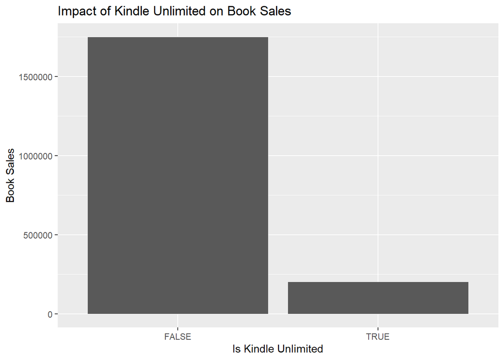

```r
#Plot the graph
ggplot(kindleUnlimitedImpact, aes(isKindleUnlimited)) +
  geom_bar(aes(weight = BookSales)) +
  labs(title = "Impact of Kindle Unlimited on Book Sales",
       x = "Is Kindle Unlimited",
       y = "Book Sales")
```

From the above chart, we can say that kindle unlimited does not have notable impact on book sales.

### Does bestseller, and editor’s pick influence book sales?

We also follow the steps used above to get total sales for each group: Best seller, and Editor’s pick. For Best Seller, we have:

```r
#Best seller impact on book sales
bestSellerImpact <- BookSalesAdded %>%
  group_by(isBestSeller) %>%
  summarise(count = n(), BookSales = sum(BookSales))
head(bestSellerImpact)
```

| isBestSeller | count | BookSales |
| --- | --- | --- |
| FALSE | 120855 | 1934662.05 |
| TRUE | 2037 | 15838.29 |

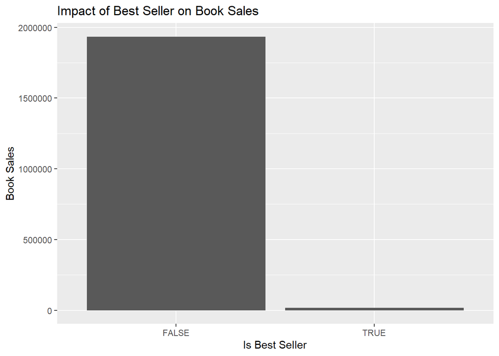

```r
#Plot the chart
ggplot(bestSellerImpact, aes(isBestSeller)) +
  geom_bar( aes(weight = BookSales)) +
  labs(title = "Impact of Best Seller on Book Sales",
       x = "Is Best Seller", y = "Book Sales")
```

There’s also no notable impact on sales. For Editor’s pick, we follow similar process to get:

```r
#Editor's pick impact on book sales
editorsPickImpact <- BookSalesAdded %>%
  group_by(isEditorsPick) %>%
  summarise(count = n(), BookSales = sum(BookSales))
head(editorsPickImpact)
```

| isEditorsPick | count | BookSales |
| --- | --- | --- |
| FALSE | 117795 | 1889757.69 |
| TRUE | 5097 | 60742.65 |

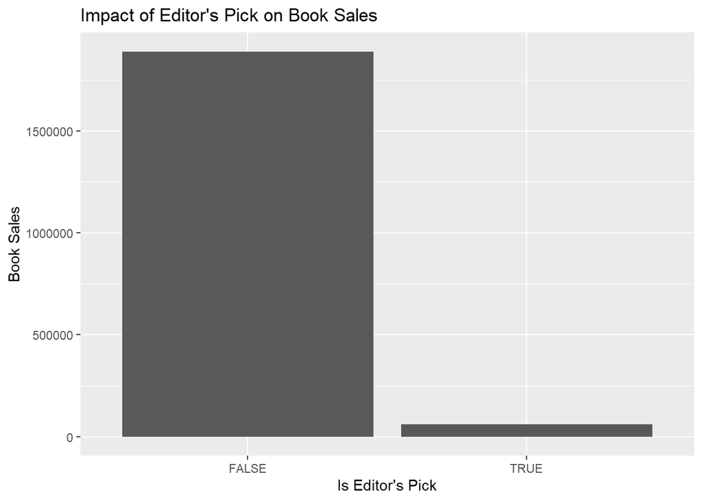

```r
#Plot the chart
ggplot(editorsPickImpact, aes(isEditorsPick)) +
  geom_bar(aes(weight = BookSales)) +
  labs(title = "Impact of Editor's Pick on Book Sales",
       x = "Is Editor's Pick", y = "Book Sales")
```

From the above analysis, we can say that Best seller’s and Editor’s pick do not influence book sales.

### Are there patterns and seasonality in book publications?

Here we need a line chart, however, we had to summarize the No. of books published per year using the SUM function. So, for each year, we had the total No. of books, and we plotted these totals in a line chart.

```r
#Uncovering patterns and seasonality
#1. Let's split the date column into day, month and year
BookSalesAdded <- BookSalesAdded %>%
  mutate(day = day(publishedDate),
         month = month(publishedDate),
         year = year(publishedDate)
  )
#2.Sum the number of books published per year. This gives us
# Total No. of books published each year from 1942 till 2023
timeSeriesData <- BookSalesAdded %>%
  group_by(year) %>%
  summarise(Books = sum(count)) %>%
  arrange(desc(Books))
head(timeSeriesData)
```

| year | Books |
| --- | --- |
| 1975 | 45776 |
| 2023 | 13591 |
| 2022 | 9977 |
| 2021 | 7695 |
| 2020 | 6931 |
| 2019 | 5584 |

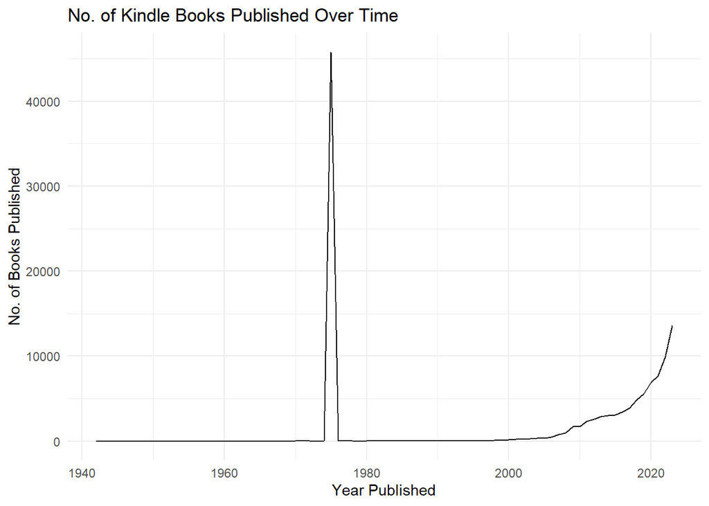

```r
#3. Plot the time series chart
ggplot(timeSeriesData, aes(x = year, y = Books )) +
  geom_line() +
  labs(title = "No. of Kindle Books Published Over Time",
       x = "Year Published",
       y = "No. of Books Published") +
  theme_minimal()
```

### Which is the most popular book genre?

Finally, we calculate total sales per book category and use a bar chart to show which category has more sales. For popularity we compute average ratings and total reviews per category.

```r
#Book sales per category
bookSalesCat <- BookSalesAdded %>%
  group_by(category_name) %>%
  summarise(TotalSales = sum(BookSales), stars = mean(stars),
            reviews = sum(reviews)) %>%
  arrange(desc(TotalSales))
head(bookSalesCat)
```

| category_name | TotalSales | stars | reviews |
| --- | --- | --- | --- |
| Law | 212335.33 | 4.023000 | 0 |
| Science & Math | 197704.26 | 4.454222 | 13777 |
| Engineering & Transportation | 168668.28 | 4.160320 | 2810 |
| Computers & Technology | 129878.50 | 4.227752 | 978059 |
| Education & Teaching | 123343.28 | 4.361115 | 1043986 |
| Medical | 98926.67 | 4.306388 | 0 |

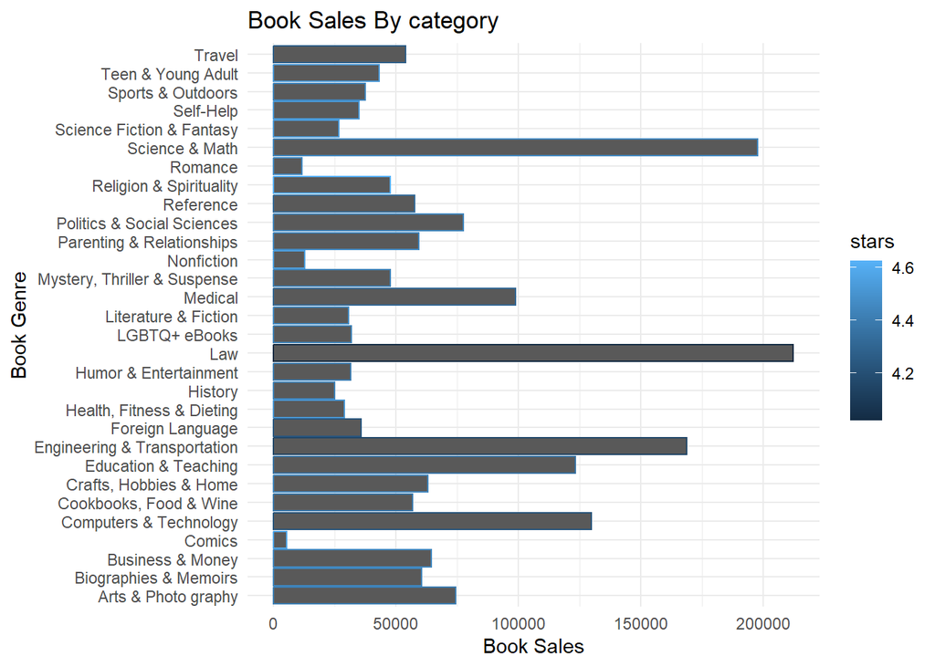

```r
#Draw a column chart for clearer understanding
ggplot(bookSalesCat, aes(category_name)) +
  geom_bar(aes(weight = TotalSales, color = stars )) +
  labs(title = "Book Sales By category",
       x = "Book Genre",
       y = "Book Sales") +
  coord_flip() +
  theme_minimal()
```

From the above, Law, and Science & Math have the most books sold.

## Predicting Book Sales

Our final analysis is to create book sales predictive model using multiple regression analysis.

From our data, a lot of variables could affect book sales. They include: price, category, rating, reviews, soldby, kindle unlimited, editor’s pick, good reads choice, and best seller.

We have data for each of these variables, but we cannot use soldby since it is of string data type, and we cannot easily one hot encode the variable.

For the our Boolean or categorical variables, we’ll use one hot encoding to assign 1 for TRUE and 0 for FALSE. Let’s quickly apply this for isKindleUnlimite, IsEditorsPick, IsBestSeller, and IsGoodReadsChoice.

So, our regression model will look thus:

$BookSales = Const. + Price + stars + reviews + category_id + isKindleUnlimited + isBestSeller + isGoodReadsChoice + isEditorsPick + u$

```r
#Predicting book sales
#1. One hot encoding isKindleUnlimite,
#IsEditorsPick, IsBestSeller, and IsGoodReadsChoice variables
#Duplicate the table
PredictionData <- BookSalesAdded
#One hot code the variables
PredictionData <- PredictionData %>%
  mutate(
    isBestSeller = as.integer(isBestSeller),
    isEditorsPick = as.integer(isEditorsPick),
    isGoodReadsChoice = as.integer(isGoodReadsChoice),
    isKindleUnlimited = as.integer(isKindleUnlimited)
  )
head(PredictionData)
```

| title | count | price | category_id | stars | reviews | BookSales | isKindleUnlimited | isBestSeller | isGoodReadsChoice | isEditorsPick | category_name | publishedDate | day | month | year |
| --- | --- | --- | --- | --- | --- | --- | --- | --- | --- | --- | --- | --- | --- | --- | --- |
| " Arrête avec tes mensonges " - Prix Maison de la presse 2017 (Hors collection) (French Edition) | 1 | 10.99 | 19 | 4.3 | 3147 | 10.99 | 0 | 0 | 0 | 0 | Foreign Language | 1975-06-17 | 17 | 6 | 1975 |
| "A Gift From The Stars" Kindle edition | 1 | 4.99 | 15 | 4.5 | 0 | 4.99 | 0 | 0 | 0 | 0 | Science & Math | 2021-05-27 | 27 | 5 | 2021 |
| "A Problem from Hell": America and the Age of Genocide | 1 | 15.99 | 14 | 4.6 | 877 | 15.99 | 0 | 0 | 0 | 0 | Politics & Social Sciences | 2013-05-14 | 14 | 5 | 2013 |
| "A" is for Alibi: A Kinsey Millhone Mystery | 1 | 9.99 | 21 | 4.1 | 0 | 9.99 | 1 | 0 | 0 | 0 | Mystery, Thriller & Suspense | 1975-06-09 | 9 | 6 | 1975 |
| "All the Real Indians Died Off": And 20 Other Myths About Native Americans (Myths Made in America Book 4) | 1 | 12.99 | 14 | 4.7 | 358 | 12.99 | 0 | 0 | 0 | 0 | Politics & Social Sciences | 1975-06-11 | 11 | 6 | 1975 |
| "An American Band, The America Story" | 1 | 8.49 | 1 | 4.3 | 237 | 8.49 | 0 | 0 | 0 | 0 | Arts & Photo graphy | 2011-04-08 | 8 | 4 | 2011 |

The conversion has successfully been made. Next, we run the correlation matrix with all 8 variables.

```r
#Correlation matrix with discrete variables only
#1. Select only numeric variables
PredictionData <- PredictionData %>%
  select_if(., is.numeric) %>%
  select(BookSales, price, stars, reviews, category_id, isKindleUnlimited,
         isBestSeller, isEditorsPick, isGoodReadsChoice)
#2. The correlation matrix, rounding up to 5 decimal places
bookPredMatrix <- round(cor(PredictionData, use = "complete.obs"),5)
bookPredMatrix[upper.tri(corMatrix)] <- 0
bookPredMatrix
```

```
##                   BookSales    price    stars  reviews category_id
## BookSales           1.00000  0.00000 -0.12283 -0.04633     0.00000
## price               0.96886  1.00000 -0.12684  0.00000    -0.08228
## stars              -0.12283 -0.12684  0.00000  0.00000     0.02599
## reviews            -0.04633  0.00000  0.03035  0.00000    -0.04622
## category_id         0.00000  0.00000  0.02599 -0.04622     0.00000
## isKindleUnlimited  -0.25118  0.00000 -0.00202  0.02475     0.00000
## isBestSeller       -0.04340 -0.04603  0.00000  0.02538    -0.00777
## isEditorsPick      -0.03396 -0.03451  0.00000  0.13067    -0.02637
## isGoodReadsChoice   0.00000 -0.02114  0.01332  0.14962     0.00000
##                   isKindleUnlimited isBestSeller isEditorsPick
## BookSales                   0.00000     -0.04340      -0.03396
## price                       0.00000     -0.04603      -0.03451
## stars                      -0.00202      0.00000       0.01557
## reviews                     0.02475      0.00000       0.13067
## category_id                 0.09712     -0.00777      -0.02637
## isKindleUnlimited           1.00000      0.11724       0.00000
## isBestSeller                0.11724      0.00000      -0.02701
## isEditorsPick               0.00000      0.00000       1.00000
## isGoodReadsChoice          -0.03073      0.00000      -0.02047
##                   isGoodReadsChoice
## BookSales                   0.00000
## price                       0.00000
## stars                       0.01332
## reviews                     0.14962
## category_id                 0.00000
## isKindleUnlimited           0.00000
## isBestSeller                0.00000
## isEditorsPick              -0.02047
## isGoodReadsChoice           1.00000
```

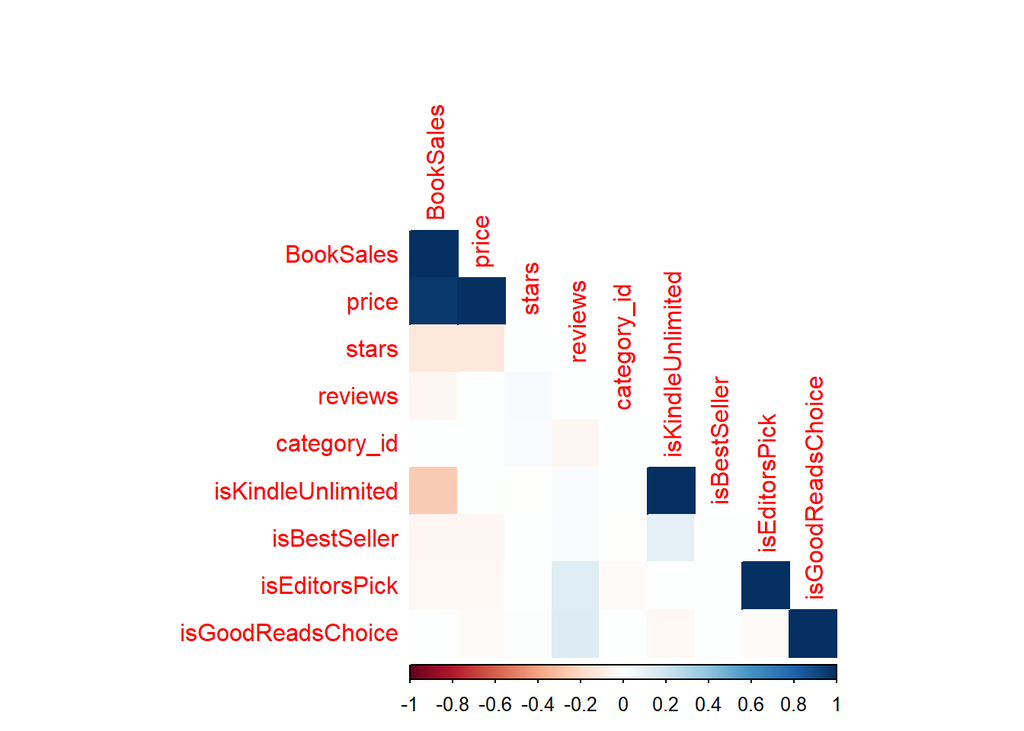

```r
#3. The matrix heatmap
corrplot(bookPredMatrix, method = "color", type = "lower")
```

Only price is highly correlated to book sales. We may remove price in our final model if it leads to the problem of multicollinearity.

```r
#The multiple regression model to predict book sales
BookSalesPredModel <- lm(BookSales ~ price + stars + reviews + category_id +
                        isKindleUnlimited + isBestSeller + isGoodReadsChoice +
                        isEditorsPick, PredictionData)

#Display the results using stargazer package to create a summary table
stargazer(BookSalesPredModel, type = "text")
```

```
##
## ===================================================
##                           Dependent variable:
##                     -------------------------------
##                                BookSales
## ---------------------------------------------------
## price                          1.045***
##                                 (0.001)
##
## stars                            0.004
##                                 (0.023)
##
## reviews                        0.00001*
##                                (0.00000)
##
## category_id                    0.012***
##                                 (0.002)
##
## isKindleUnlimited              0.241***
##                                 (0.040)
##
## isBestSeller                     0.143
##                                 (0.135)
##
## isGoodReadsChoice                0.018
##                                 (0.178)
##
## isEditorsPick                   -0.010
##                                 (0.087)
##
## Constant                       -0.739***
##                                 (0.111)
##
## ---------------------------------------------------
## Observations                    122,892
## R2                               0.939
## Adjusted R2                      0.939
## Residual Std. Error       5.995 (df = 122883)
## F Statistic         235,332.700*** (df = 8; 122883)
## ===================================================
## Note:                   *p<0.1; **p<0.05; ***p<0.01
```

The result shows that only 3 variables (price, isKindleUnlimited and category_id) and constant are statistically significant at 5%.

Let’s remove price and see if multicollinearity played a role.

```r
#The regression model to predict book sales without price variable
BookSalesPredModel1 <- lm(BookSales ~ stars + reviews + category_id +
                           isKindleUnlimited + isBestSeller + isGoodReadsChoice +
                           isEditorsPick, PredictionData)

#Display the results using stargazer package to create a summary table
stargazer(BookSalesPredModel1, type = "text")
```

```
##
## =================================================
##                          Dependent variable:
##                     -----------------------------
##                               BookSales
## -------------------------------------------------
## stars                         -3.869***
##                                (0.088)
##
## reviews                      -0.0001***
##                               (0.00001)
##
## category_id                   -0.146***
##                                (0.008)
##
## isKindleUnlimited            -13.568***
##                                (0.151)
##
## isBestSeller                  -2.644***
##                                (0.522)
##
## isGoodReadsChoice             -6.107***
##                                (0.687)
##
## isEditorsPick                 -6.545***
##                                (0.336)
##
## Constant                      39.411***
##                                (0.410)
##
## -------------------------------------------------
## Observations                   122,892
## R2                              0.086
## Adjusted R2                     0.085
## Residual Std. Error     23.162 (df = 122884)
## F Statistic         1,642.287*** (df = 7; 122884)
## =================================================
## Note:                 *p<0.1; **p<0.05; ***p<0.01
```

Great! Though price made the model a great fit, it neutralized other relevant variables. So far, all our variables are statistically significant at 1% level of significance. However, they are all negative, and it should not be so.

As a result, the first regression model would likely be the best for book sales prediction. The model is therefore represented thus:

$BookSales = -0.739 + 1.045Price + 0.004stars + 0.00001reviews + 0.012category_id + 0.241isKindleUnlimited + 0.143isBestSeller + 0.018isGoodReadsChoice - 0.01isEditorsPick$

## Conclusion

Haven explored and analysed our data; we can still create a dashboard for easy assessment and sharing. You can use any of Tableau, Power BI, or Looker Studio to create a dashboard.

Let’s create a csv file to export our cleaned data so we can easily use it in any dashboard reporting tool.

```r
#Export the cleaned data "salesData_rev" to csv for use in Looker studio
write.csv(salesData_rev,
          "C:\\Users\\Kmacims\\Desktop\\Movies\\Tutorials\\Projects\\Looker Studio\\KindleData_clean.csv")

write.csv(BookSalesAdded,
          "C:\\Users\\Kmacims\\Desktop\\Movies\\Tutorials\\Projects\\Looker Studio\\KindleData_cleanwithsales.csv")
```